# Forecast births in France

# Preparation of the data

We clean the environnment.

```r
rm(list = ls())
```

- **The libraries that we will need.**

```r
library(tidyverse)
library(forecast)
```

We prepare the data

```r
mydata = read.csv("valeurs_mensuelles.csv", header=TRUE, sep=";", col.names = c("period","Births","codes"))
mydata = mydata[c(-1,-2),] # We exclude the first two rows.
rownames(mydata) = NULL # To exclude the rows numbers.
mydata = mydata %>% arrange(-row_number()) # We reverse the order of the rows
head(mydata, n=1) # start 1946-01
```

|  | period | Births | codes |
| --- | --- | --- | --- |
| 1 | 1946-01 | 64599 | A |

```r
tail(mydata, n=1) # end 2018-12
```

|  | period | Births | codes |
| --- | --- | --- | --- |
| 876 | 2018-12 | 59800 | P |

```r
dim(mydata)[1] # 876 observations
```

```
[1] 876
```

```r
mydata = mydata %>% select(Births) # We only keep the column that we are interested in.
```

We transform the data to a time series.

```r
birth_ts = ts(mydata,start = c(1946, 1), end=c(2018,12), frequency = 12)
#birth_ts = window(birth_ts, start=c(2009,01)) # if we want to restrict last 10 years
```

# Plot

We plot the time series.

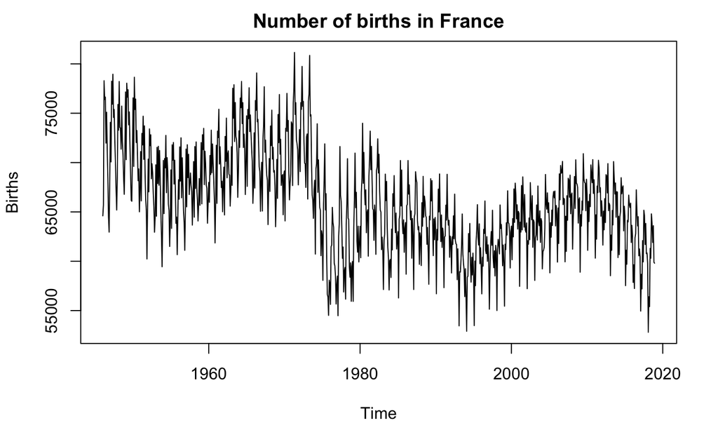

```r
plot(birth_ts, main="Number of births in France")
```

We see a downward trend with some bumps in the number of births. It is difficult to see if there is seasonality.

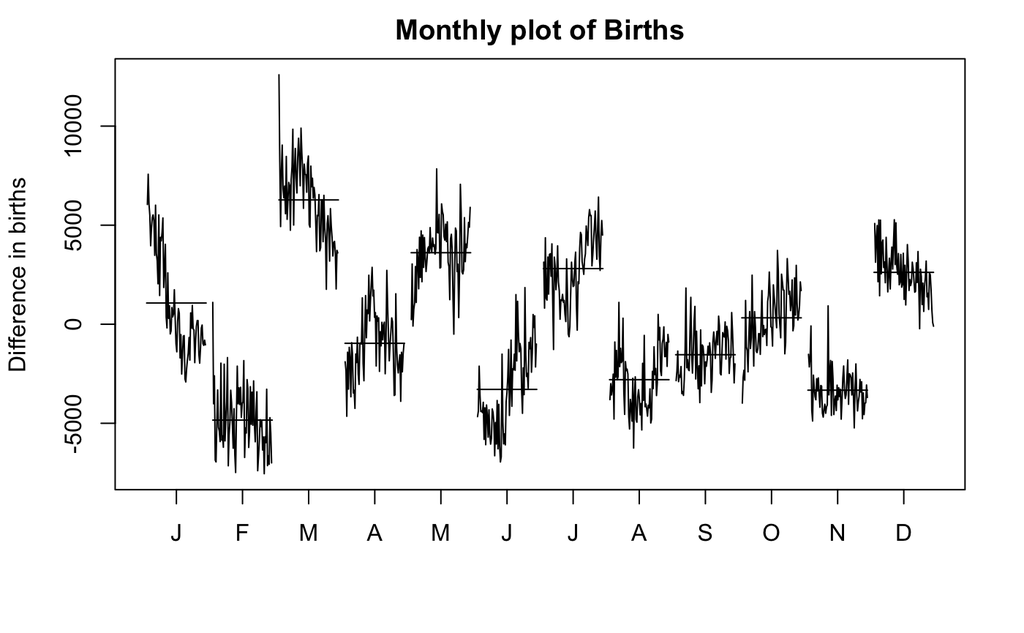

```r
monthplot(diff(birth_ts, lag=1), main = "Monthly plot of Births", ylab="Difference in births")
```

When we remove the trend, it is clear that there is seasonality. We should go in seasonal differences.

Let’s try to create a stationary time series

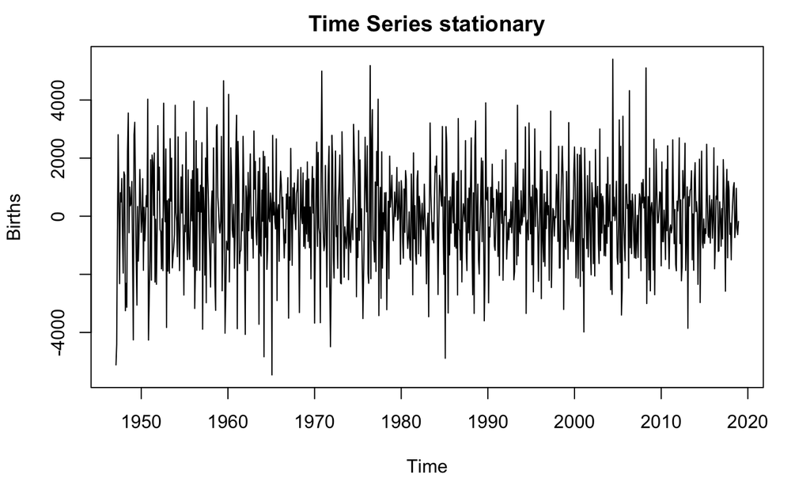

```r
birth_ts_s= diff(diff(birth_ts, lag=12),lag=1) # _s for stationary
plot(birth_ts_s, main="Time Series stationary")
```

It seems that we have remove the trend and the seasonality. The variance does not seem to increase, we have no reason to go in log. We can now rely on the concept of stationarity.

Visual proof of no more seasonality

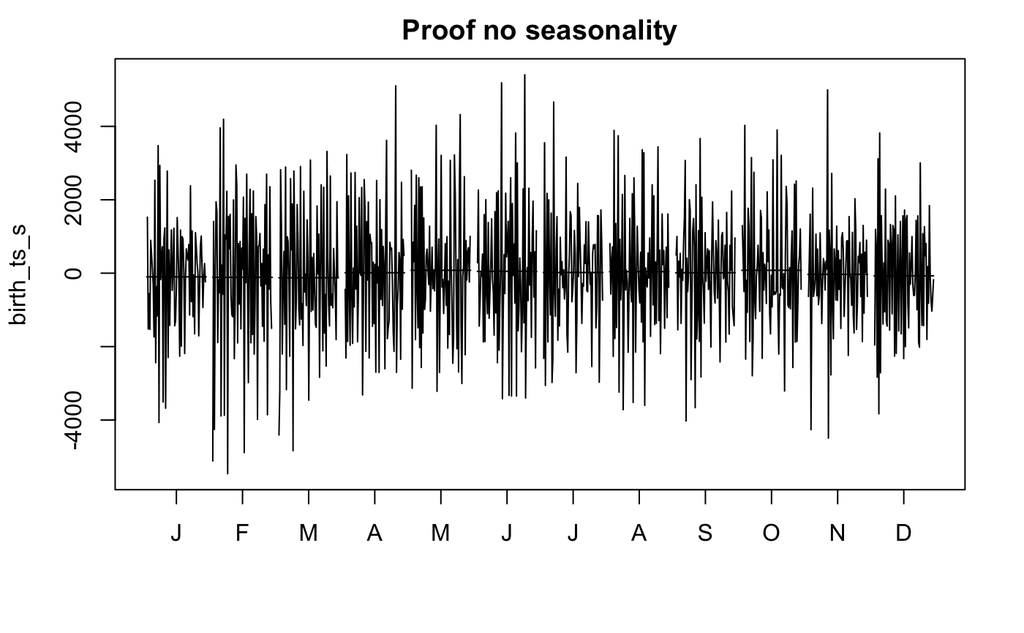

```r
monthplot(birth_ts_s, main="Proof no seasonality")
```

All the months have the same mean.

Is ts_s white noise ? We check:

```r
Box.test(birth_ts_s, lag=20, type="Ljung-Box")
```

```
    Box-Ljung test

data:  birth_ts_s
X-squared = 264.07, df = 20, p-value < 2.2e-16
```

We can strongly reject than birth_ts_s is a white noise. In our models, we will go in differences and in seasonal differences.

# Modelling

Correlogram of the series

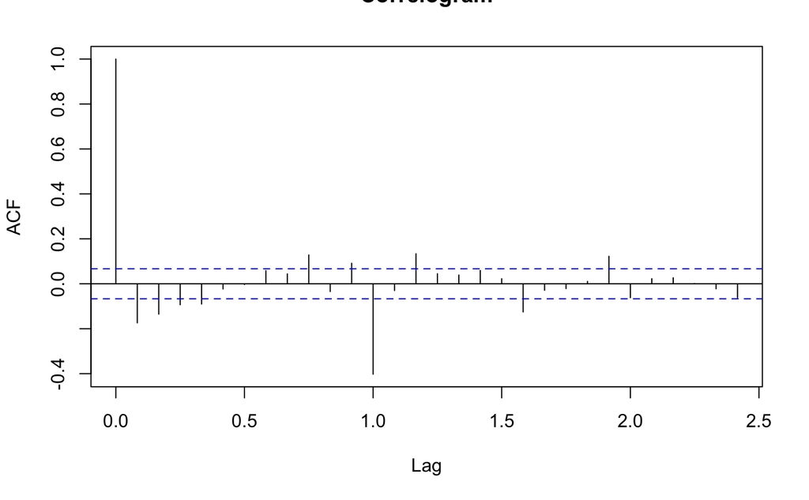

```r
acf(birth_ts_s, main="Correlogram")
```

The Correlogram indicates that a Moving average MA(4) repeated once or twice could be appropriate.

Partial Correlogram

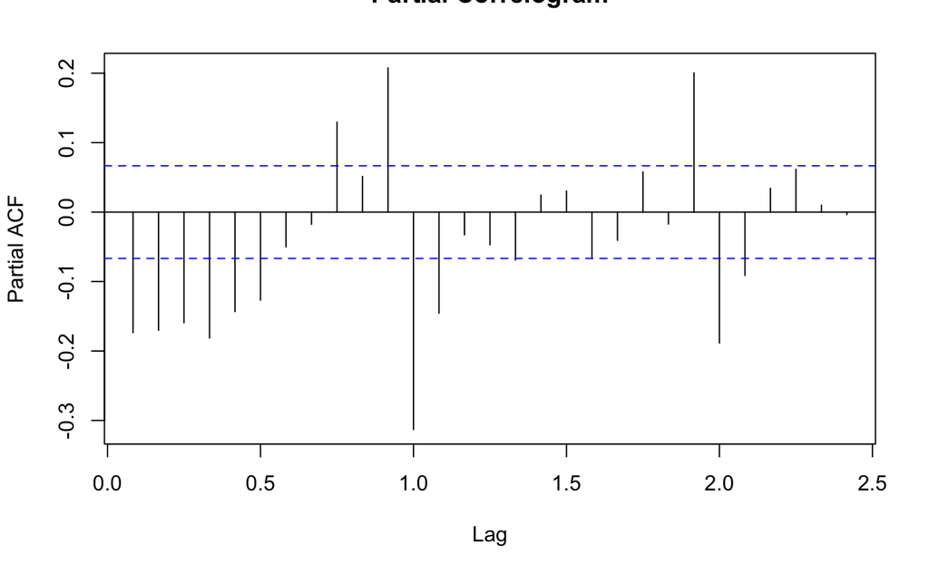

```r
pacf(birth_ts_s, main= "Partial Correlogram")
```

It indicates that a AR(6) repeated once or twice could be appropriate.

Let’s try different models to remove the autocorrelation * **auto_arima: ARIMA(3,0,1)(2,1,2)**

```r
model_auto = auto.arima(birth_ts)
summary(model_auto)
```

```
Series: birth_ts
ARIMA(3,0,1)(2,1,2)[12]

Coefficients:
```

```
NaNs produced
```

```
         ar1      ar2     ar3      ma1     sar1    sar2     sma1     sma2
      1.4794  -0.5835  0.0903  -0.7623  -0.3937  0.0392  -0.2892  -0.3664
s.e.  0.0564   0.0649  0.0379   0.0435      NaN     NaN      NaN      NaN

sigma^2 estimated as 1697930:  log likelihood=-7423.58
AIC=14865.17   AICc=14865.38   BIC=14908.02

Training set error measures:
                    ME     RMSE      MAE         MPE     MAPE      MASE        ACF1
Training set -34.42779 1288.086 997.1989 -0.07983187 1.513979 0.5969538 -0.01832825
```

```r
Box.test(model_auto$res, lag=10, type="Ljung-Box")
```

```
    Box-Ljung test

data:  model_auto$res
X-squared = 18.644, df = 10, p-value = 0.04503
```

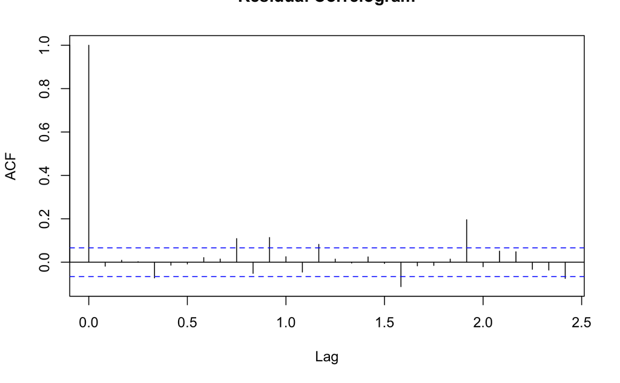

```r
acf(model_auto$res, main="Residual Correlogram")
```

We can reject that the residuals are white noise. We reject this model.

- **AR(6) repeated once**

```r
model1 = arima(birth_ts, order=c(6, 1, 0), seasonal=c(2,1,0))
summary(model1)
```

```
Call:
arima(x = birth_ts, order = c(6, 1, 0), seasonal = c(2, 1, 0))

Coefficients:
          ar1      ar2      ar3      ar4      ar5      ar6     sar1     sar2
      -0.3310  -0.3156  -0.2222  -0.2526  -0.1464  -0.0884  -0.5251  -0.2630
s.e.   0.0347   0.0366   0.0376   0.0371   0.0370   0.0351   0.0346   0.0343

sigma^2 estimated as 1898460:  log likelihood = -7464.79,  aic = 14947.58

Training set error measures:
                    ME     RMSE      MAE         MPE     MAPE      MASE        ACF1
Training set -32.24219 1367.604 1066.724 -0.05938243 1.619533 0.3492617 0.002649014
```

```r
Box.test(model1$res, lag=10, type="Ljung-Box")
```

```
    Box-Ljung test

data:  model1$res
X-squared = 14.335, df = 10, p-value = 0.1582
```

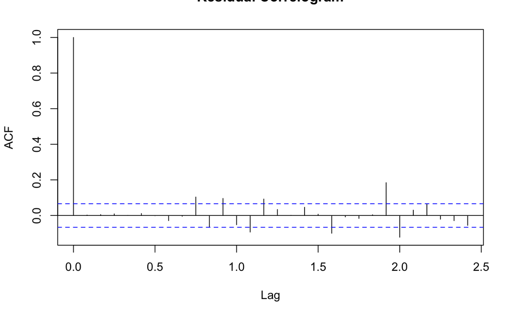

```r
acf(model1$res, main="Residual Correlogram")
```

**Our model is validated. Our residuals are white noise.**

- **MA(4) repeated once.**

```r
model2 = arima(birth_ts, order=c(0, 1, 4), seasonal=c(0,1,1))
summary(model2)
```

```
Call:
arima(x = birth_ts, order = c(0, 1, 4), seasonal = c(0, 1, 1))

Coefficients:
          ma1      ma2      ma3      ma4     sma1
      -0.2713  -0.2054  -0.0701  -0.0767  -0.7404
s.e.   0.0355   0.0365   0.0357   0.0357   0.0237

sigma^2 estimated as 1701567:  log likelihood = -7420.29,  aic = 14852.59

Training set error measures:
                    ME     RMSE      MAE         MPE     MAPE      MASE        ACF1
Training set -48.45503 1294.747 995.6268 -0.08945584 1.511452 0.3259834 0.004883061
```

```r
Box.test(model2$res, lag=10, type="Ljung-Box")
```

```
    Box-Ljung test

data:  model2$res
X-squared = 13.017, df = 10, p-value = 0.2227
```

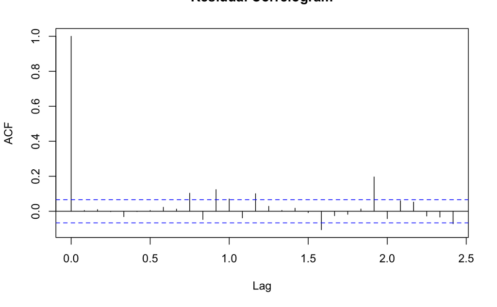

```r
acf(model2$res, main="Residual Correlogram")
```

**Our model is validated. Our residuals are white noise.**

- **ARMA(2,2) repeated twice.**

```r
model3 = arima(birth_ts, order=c(2, 1, 2), seasonal=c(1,1,1))
summary(model3)
```

```
Call:
arima(x = birth_ts, order = c(2, 1, 2), seasonal = c(1, 1, 1))

Coefficients:
         ar1      ar2      ma1     ma2    sar1     sma1
      1.3520  -0.5714  -1.6253  0.7242  0.0566  -0.7748
s.e.  0.0828   0.0600   0.0785  0.0680  0.0457   0.0267

sigma^2 estimated as 1677837:  log likelihood = -7414.26,  aic = 14842.52

Training set error measures:
                    ME     RMSE      MAE         MPE     MAPE      MASE          ACF1
Training set -44.12573 1285.687 995.0669 -0.08121706 1.510633 0.3258001 -0.0005939096
```

```r
Box.test(model3$res, lag=10, type="Ljung-Box")
```

```
    Box-Ljung test

data:  model3$res
X-squared = 14.641, df = 10, p-value = 0.1457
```

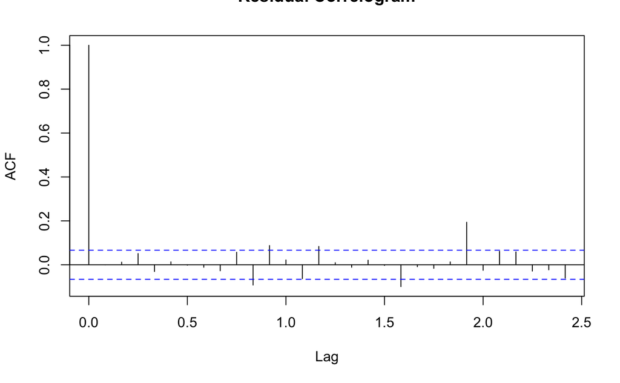

```r
acf(model3$res, main="Residual Correlogram")
```

# In-Sample Comparison

The BIC penalizes even more for the complexity of the model. This is the more popular criterion in time series analysis.

```r
BIC(model1)
```

```
[1] 14990.42
```

```r
BIC(model2)
```

```
[1] 14881.15
```

```r
BIC(model3)
```

```
[1] 14875.84
```

# Out-of-sample Comparison

We compare the two models with the lowest BIC (model 3 and model 2)

We generate out-of-sample forecast errors for ARMA(2,2) (model3):

```r
y<-birth_ts
S=round(length(y)/2);h=4;
error1.h<-c()
for (i in S:(length(y)-h)) {
mymodel.sub<-arima(y[1:i],order=c(2, 1, 2), seasonal=c(1,1,1))
predict.h<-predict(mymodel.sub,n.ahead=h)$pred[h]
error1.h<-c(error1.h,y[i+h]-predict.h)
}
MAE3<-mean(abs(error1.h))
MAPE1<-mean(abs(error1.h)/length(error1.h))
```

We generate out-of-sample forecast errors for MA(4) (model 2):

```r
error2.h<-c()
for (i in S:(length(y)-h)) {
mymodel.sub<-arima(y[1:i],order=c(0, 1, 4), seasonal=c(0,1,1))
predict.h<-predict(mymodel.sub,n.ahead=h)$pred[h]
error2.h<-c(error1.h,y[i+h]-predict.h)
}
MAE2<-mean(abs(error2.h))
MAPE2<-mean(abs(error2.h)/length(error2.h))
```

We compute a Diebold Mariano test to assess the significance of the difference in MAE and MAPE between our 2 models.

```r
dm.test(error1.h,error2.h,h=h,power=1)
```

```
longer object length is not a multiple of shorter object length
```

```
    Diebold-Mariano Test

data:  error1.herror2.h
DM = 0.99314, Forecast horizon = 4, Loss function power = 1, p-value = 0.3212
alternative hypothesis: two.sided
```

We conclude that the forecast performance of the two models, measured by the MAE, is not significantly different.

Thus, we stick to the BIC criteria and chose model 3.

# Forecast with the best model. (or with average equal model ?)

```r
myforecast = predict(model3,n.ahead=4)
alpha = 0.05
q=qnorm(1-alpha/2)
prediction = myforecast$pred
lower = prediction - q*myforecast$se # lower bound CI
upper = prediction + q*myforecast$se # upper bound CI
cbind(lower, prediction, upper) # probability 95%
```

```
            lower prediction    upper
Jan 2019 56577.78   59116.55 61655.32
Feb 2019 50079.19   53217.64 56356.10
Mar 2019 53652.18   57047.40 60442.62
Apr 2019 52004.22   55529.33 59054.44
```

```r
plot(birth_ts, main="Forecast", xlim=c(2018,2020), ylim=c(50000, 75000))
lines(prediction,col="red")
```

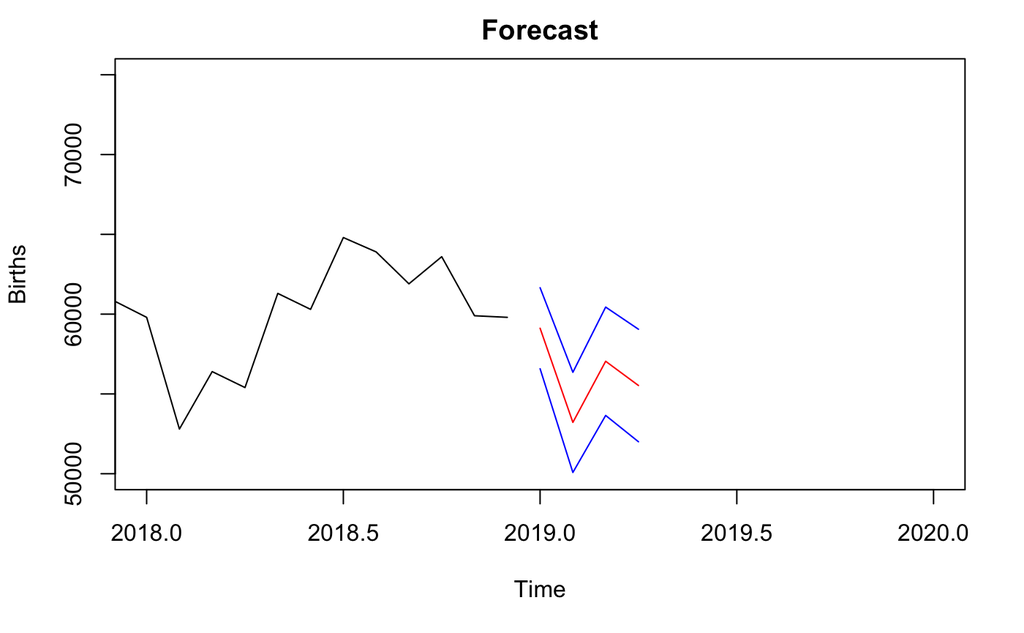

```r
lines(lower,col="blue")
lines(upper,col="blue")
```